# Tomey - Assignment 12 - Connectivity

# Challenge 4 (5 points)

In the latter part of the lab, we discussed calculating patch-based and landscape-based metrics of connectivity. Patch number 6 had the lowest degree (n = 2) while patch number 7 had one of the highest degrees (n = 12). First delete patch number 6 from the network, and then examine the impacts on the landscape level metrics integral index of connectivity (ICC) and probability of connectivity (PC). Now replace patch 6 back into the network and instead delete patch number 7. Again, examine how ICC and PC change.

### Second Dataset

```r
nodes = read.csv('https://raw.githubusercontent.com/ValenteJJ/SpatialEcology/main/Week12/kite_nodes.csv')
area = nodes$area
nodes
```

| Name | XCoord | YCoord | area |
| --- | --- | --- | --- |
| BICY | 495505 | 2849390 | 848.2403875 |
| DEVILS | 497670 | 2925290 | 0.6780510 |
| ENP | 531302 | 2840110 | 638.3016839 |
| ETOHO | 472324 | 3130400 | 47.5983906 |
| GW | 582883 | 2962720 | 20.2262642 |
| HarnsMarsh | 431024 | 2948020 | 2.2809754 |
| HOLEY | 526531 | 2917990 | 143.6203120 |
| HUNGRY | 569598 | 2983060 | 46.5866850 |
| IST | 472176 | 3028470 | 109.8500706 |
| KISS | 473993 | 3087280 | 145.0277254 |

[output cut: 19 more lines]

```r
aObs = read.csv('https://raw.githubusercontent.com/ValenteJJ/SpatialEcology/main/Week12/kite_movement.csv')[,-1]
diag(aObs) = 0
aObs
```

| V1 | V2 | V3 | V4 | V5 | V6 | V7 | V8 | V9 | V10 | V11 | V12 | V13 | V14 | V15 | V16 | V17 | V18 | V19 | V20 | V21 | V22 | V23 | V24 | V25 | V26 | V27 | V28 | V29 |
| --- | --- | --- | --- | --- | --- | --- | --- | --- | --- | --- | --- | --- | --- | --- | --- | --- | --- | --- | --- | --- | --- | --- | --- | --- | --- | --- | --- | --- |
| 0 | 0 | 0 | 0 | 0 | 0 | 0 | 0 | 0 | 0 | 0 | 0 | 0 | 0 | 0 | 0 | 0 | 0 | 0 | 0 | 0 | 0 | 0 | 0 | 0 | 0 | 0 | 0 | 0 |
| 0 | 0 | 0 | 0 | 0 | 0 | 0 | 0 | 0 | 0 | 0 | 0 | 0 | 0 | 0 | 0 | 0 | 0 | 0 | 0 | 0 | 0 | 0 | 0 | 0 | 0 | 0 | 0 | 0 |
| 0 | 0 | 0 | 0 | 1 | 0 | 0 | 0 | 0 | 0 | 0 | 0 | 0 | 0 | 0 | 0 | 0 | 0 | 0 | 0 | 0 | 0 | 0 | 0 | 0 | 1 | 1 | 0 | 0 |
| 0 | 0 | 0 | 0 | 0 | 0 | 0 | 0 | 2 | 11 | 0 | 0 | 0 | 2 | 0 | 0 | 17 | 5 | 0 | 0 | 0 | 0 | 0 | 10 | 0 | 0 | 0 | 0 | 0 |
| 0 | 0 | 0 | 0 | 0 | 0 | 0 | 0 | 0 | 0 | 0 | 0 | 0 | 0 | 0 | 0 | 0 | 0 | 0 | 1 | 0 | 0 | 0 | 0 | 0 | 1 | 1 | 0 | 0 |
| 0 | 0 | 0 | 0 | 0 | 0 | 0 | 0 | 0 | 0 | 0 | 0 | 0 | 0 | 0 | 0 | 0 | 1 | 0 | 0 | 0 | 0 | 0 | 1 | 0 | 0 | 0 | 0 | 0 |
| 0 | 0 | 0 | 0 | 0 | 0 | 0 | 0 | 0 | 0 | 0 | 0 | 0 | 0 | 0 | 0 | 0 | 0 | 0 | 0 | 0 | 0 | 0 | 0 | 0 | 0 | 0 | 0 | 0 |
| 0 | 0 | 0 | 0 | 0 | 0 | 0 | 0 | 0 | 0 | 0 | 0 | 0 | 0 | 0 | 0 | 0 | 0 | 0 | 0 | 0 | 0 | 0 | 0 | 0 | 0 | 0 | 0 | 0 |
| 0 | 0 | 0 | 0 | 0 | 0 | 0 | 0 | 0 | 2 | 0 | 0 | 0 | 0 | 0 | 0 | 0 | 1 | 0 | 0 | 0 | 0 | 2 | 1 | 0 | 0 | 0 | 0 | 0 |
| 0 | 0 | 0 | 13 | 1 | 0 | 0 | 0 | 5 | 0 | 0 | 0 | 0 | 1 | 0 | 0 | 3 | 18 | 0 | 3 | 0 | 0 | 1 | 48 | 0 | 0 | 1 | 0 | 0 |

[output cut: 19 more lines]

```r
coords = cbind(nodes$XCoord, nodes$YCoord)
distMat = pointDistance(coords, lonlat=F)
distMat = distMat / 1000 # in km
distMat
```

```
           [,1]      [,2]      [,3]       [,4]      [,5]      [,6]      [,7]      [,8]
 [1,]   0.00000  75.93087  36.98031 281.964499 143.10347 117.83750  75.28992 152.83142
 [2,]  75.93087   0.00000  91.57917 206.670104  93.07126  70.41550  29.76991  92.25514
 [3,]  36.98031  91.57917   0.00000 296.220675 133.01809 147.31003  78.02600 147.99083
 [4,] 281.96450 206.67010 296.22068   0.000000 200.84789 186.99774 219.21772 176.55398
 [5,] 143.10347  93.07126 133.01809 200.847890   0.00000 152.56882  71.94665  24.29417
 [6,] 117.83750  70.41550 147.31003 186.997739 152.56882   0.00000 100.11687 142.93549
 [7,]  75.28992  29.76991  78.02600 219.217716  71.94665 100.11687   0.00000  78.03122
 [8,] 152.83142  92.25514 147.99083 176.553977  24.29417 142.93549  78.03122   0.00000
 [9,] 180.59316 106.28291 197.42182 101.930107 128.75986  90.36421 123.12716 107.48541
[10,] 238.86067 163.71121 253.72688  43.152288 165.44554 145.73840 177.25503 141.42887
[11,] 117.22234  51.04710 140.00161 169.038197 121.01143  33.74282  78.03539 109.82222
[12,] 258.04741 183.08540 273.26274  24.753922 183.50949 162.28823 196.83777 159.34524
[13,] 253.37885 179.01276 269.79689  32.730882 184.63787 154.86972 194.11347 160.66645
[14,] 237.99453 162.38991 251.47406  44.857074 158.85685 148.86453 174.36719 134.68572
```

[output cut: 105 more lines]

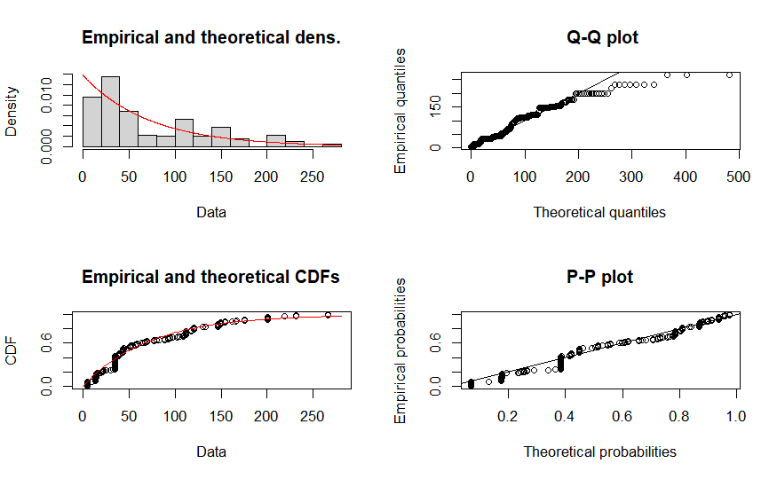

```r
linkLoc = which(aObs > 0, arr.ind=T)
withinDisp = cbind(distMat[linkLoc], aObs[linkLoc])

#Creating one distance observation for each individual
withinDisp = rep(withinDisp[,1], withinDisp[,2])

dispExp = fitdist(data = withinDisp, distr='exp', method='mle')
plot(dispExp)
```

```r
aObs
```

| V1 | V2 | V3 | V4 | V5 | V6 | V7 | V8 | V9 | V10 | V11 | V12 | V13 | V14 | V15 | V16 | V17 | V18 | V19 | V20 | V21 | V22 | V23 | V24 | V25 | V26 | V27 | V28 | V29 |
| --- | --- | --- | --- | --- | --- | --- | --- | --- | --- | --- | --- | --- | --- | --- | --- | --- | --- | --- | --- | --- | --- | --- | --- | --- | --- | --- | --- | --- |
| 0 | 0 | 0 | 0 | 0 | 0 | 0 | 0 | 0 | 0 | 0 | 0 | 0 | 0 | 0 | 0 | 0 | 0 | 0 | 0 | 0 | 0 | 0 | 0 | 0 | 0 | 0 | 0 | 0 |
| 0 | 0 | 0 | 0 | 0 | 0 | 0 | 0 | 0 | 0 | 0 | 0 | 0 | 0 | 0 | 0 | 0 | 0 | 0 | 0 | 0 | 0 | 0 | 0 | 0 | 0 | 0 | 0 | 0 |
| 0 | 0 | 0 | 0 | 1 | 0 | 0 | 0 | 0 | 0 | 0 | 0 | 0 | 0 | 0 | 0 | 0 | 0 | 0 | 0 | 0 | 0 | 0 | 0 | 0 | 1 | 1 | 0 | 0 |
| 0 | 0 | 0 | 0 | 0 | 0 | 0 | 0 | 2 | 11 | 0 | 0 | 0 | 2 | 0 | 0 | 17 | 5 | 0 | 0 | 0 | 0 | 0 | 10 | 0 | 0 | 0 | 0 | 0 |
| 0 | 0 | 0 | 0 | 0 | 0 | 0 | 0 | 0 | 0 | 0 | 0 | 0 | 0 | 0 | 0 | 0 | 0 | 0 | 1 | 0 | 0 | 0 | 0 | 0 | 1 | 1 | 0 | 0 |
| 0 | 0 | 0 | 0 | 0 | 0 | 0 | 0 | 0 | 0 | 0 | 0 | 0 | 0 | 0 | 0 | 0 | 1 | 0 | 0 | 0 | 0 | 0 | 1 | 0 | 0 | 0 | 0 | 0 |
| 0 | 0 | 0 | 0 | 0 | 0 | 0 | 0 | 0 | 0 | 0 | 0 | 0 | 0 | 0 | 0 | 0 | 0 | 0 | 0 | 0 | 0 | 0 | 0 | 0 | 0 | 0 | 0 | 0 |
| 0 | 0 | 0 | 0 | 0 | 0 | 0 | 0 | 0 | 0 | 0 | 0 | 0 | 0 | 0 | 0 | 0 | 0 | 0 | 0 | 0 | 0 | 0 | 0 | 0 | 0 | 0 | 0 | 0 |
| 0 | 0 | 0 | 0 | 0 | 0 | 0 | 0 | 0 | 2 | 0 | 0 | 0 | 0 | 0 | 0 | 0 | 1 | 0 | 0 | 0 | 0 | 2 | 1 | 0 | 0 | 0 | 0 | 0 |
| 0 | 0 | 0 | 13 | 1 | 0 | 0 | 0 | 5 | 0 | 0 | 0 | 0 | 1 | 0 | 0 | 3 | 18 | 0 | 3 | 0 | 0 | 1 | 48 | 0 | 0 | 1 | 0 | 0 |

[output cut: 19 more lines]

```r
aMeanDist = mean(withinDisp)
aMeanDist
```

```
[1] 72.32945
```

```r
aMean = matrix(0, nrow=nrow(aObs), ncol=ncol(aObs))
aMean[distMat < aMeanDist] = 1
diag(aMean) = 0
aMean
```

```
      [,1] [,2] [,3] [,4] [,5] [,6] [,7] [,8] [,9] [,10] [,11] [,12] [,13] [,14] [,15]
 [1,]    0    0    1    0    0    0    0    0    0     0     0     0     0     0     0
 [2,]    0    0    0    0    0    1    1    0    0     0     1     0     0     0     0
 [3,]    1    0    0    0    0    0    0    0    0     0     0     0     0     0     0
 [4,]    0    0    0    0    0    0    0    0    0     1     0     1     1     1     1
 [5,]    0    0    0    0    0    0    1    1    0     0     0     0     0     0     0
 [6,]    0    1    0    0    0    0    0    0    0     0     1     0     0     0     0
 [7,]    0    1    0    0    1    0    0    0    0     0     0     0     0     0     0
 [8,]    0    0    0    0    1    0    0    0    0     0     0     0     0     0     0
 [9,]    0    0    0    0    0    0    0    0    0     1     1     0     0     1     1
[10,]    0    0    0    1    0    0    0    0    1     0     0     1     1     1     1
[11,]    0    1    0    0    0    1    0    0    1     0     0     0     0     0     0
[12,]    0    0    0    1    0    0    0    0    0     1     0     0     1     1     1
[13,]    0    0    0    1    0    0    0    0    0     1     0     1     0     1     1
[14,]    0    0    0    1    0    0    0    0    1     1     0     1     1     0     1
```

[output cut: 45 more lines]

```r
aProb = matrix(0, nrow=nrow(aObs), ncol=ncol(aObs))
alpha = 1/aMeanDist

# Calculate weights in the distance matrix
aProb = exp(-alpha*distMat)
diag(aProb)=0
aProb
```

```
            [,1]       [,2]       [,3]       [,4]       [,5]       [,6]       [,7]
 [1,] 0.00000000 0.35001058 0.59972982 0.02027562 0.13827716 0.19609083 0.35312598
 [2,] 0.35001058 0.00000000 0.28191790 0.05742108 0.27616174 0.37774407 0.66259746
 [3,] 0.59972982 0.28191790 0.00000000 0.01664848 0.15896703 0.13046458 0.34001744
 [4,] 0.02027562 0.05742108 0.01664848 0.00000000 0.06223436 0.07536887 0.04827592
 [5,] 0.13827716 0.27616174 0.15896703 0.06223436 0.00000000 0.12131563 0.36983158
 [6,] 0.19609083 0.37774407 0.13046458 0.07536887 0.12131563 0.00000000 0.25052952
 [7,] 0.35312598 0.66259746 0.34001744 0.04827592 0.36983158 0.25052952 0.00000000
 [8,] 0.12087599 0.27929545 0.12924234 0.08707640 0.71470732 0.13859867 0.33999290
 [9,] 0.08234697 0.23005708 0.06525319 0.24432704 0.16860681 0.28669344 0.18226199
[10,] 0.03679481 0.10399524 0.02995877 0.55067668 0.10153129 0.13333043 0.08623649
[11,] 0.19776569 0.49373410 0.14433620 0.09661135 0.18767213 0.62718377 0.33997331
[12,] 0.02822161 0.07955788 0.02286773 0.71017882 0.07909278 0.10606147 0.06578223
[13,] 0.03010327 0.08416605 0.02399017 0.63602020 0.07786846 0.11751715 0.06830718
[14,] 0.03723807 0.10591247 0.03090657 0.53784914 0.11121439 0.12769056 0.08974924
```

[output cut: 135 more lines]

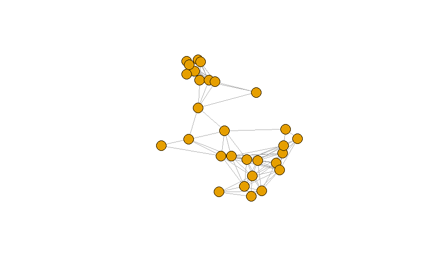

```r
graphAmean = graph_from_adjacency_matrix(aMean, mode='undirected')
graphAprob = graph_from_adjacency_matrix(aProb, mode='undirected', weighted=T)
graphAobs = graph_from_adjacency_matrix(as.matrix(aObs), mode='directed', weighted=T)

plot(graphAmean, layout=coords, vertex.label=NA)
```

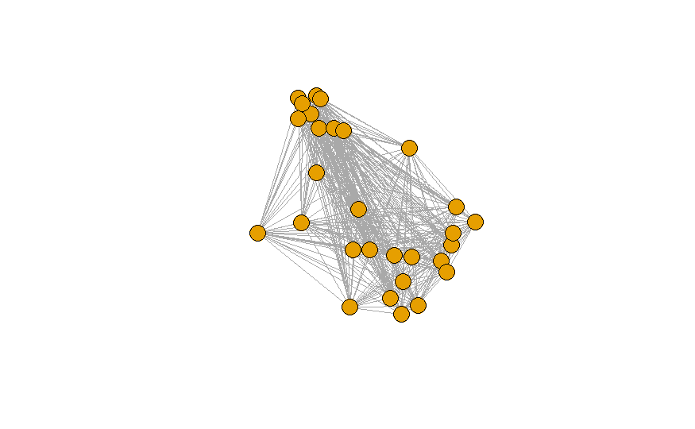

```r
plot(graphAprob, layout=coords, edge.width=E(graphAprob)$weight, vertex.label=NA)
```

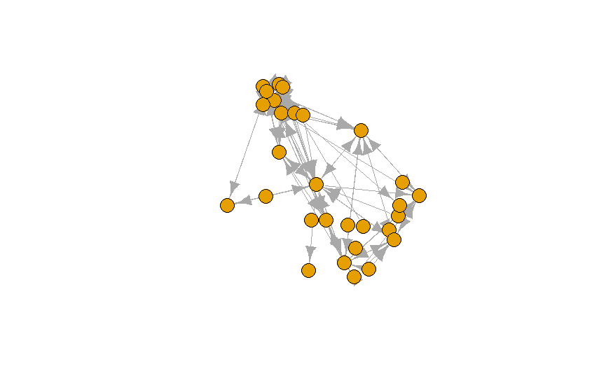

```r
plot(graphAobs, layout=coords, vertex.label=NA)
```

### Patch 6 Removed

```r
nodes6 = read.csv('https://github.com/rytomey/WILD7970_Spatial/raw/main/W12_Connectivity/kite6.csv')
area6 = nodes6$area
nodes6
```

| Name | XCoord | YCoord | area |
| --- | --- | --- | --- |
| BICY | 495505 | 2849390 | 848.2403875 |
| DEVILS | 497670 | 2925290 | 0.6780510 |
| ENP | 531302 | 2840110 | 638.3016839 |
| ETOHO | 472324 | 3130400 | 47.5983906 |
| GW | 582883 | 2962720 | 20.2262642 |
| HOLEY | 526531 | 2917990 | 143.6203120 |
| HUNGRY | 569598 | 2983060 | 46.5866850 |
| IST | 472176 | 3028470 | 109.8500706 |
| KISS | 473993 | 3087280 | 145.0277254 |
| LaBelle | 461876 | 2961685 | 3.8620990 |

[output cut: 18 more lines]

```r
aObs6 = read.csv('https://github.com/rytomey/WILD7970_Spatial/raw/main/W12_Connectivity/kitemove6.csv')[,-1]
diag(aObs6) = 0
aObs6
```

| V1 | V2 | V3 | V4 | V5 | V7 | V8 | V9 | V10 | V11 | V12 | V13 | V14 | V15 | V16 | V17 | V18 | V19 | V20 | V21 | V22 | V23 | V24 | V25 | V26 | V27 | V28 | V29 |
| --- | --- | --- | --- | --- | --- | --- | --- | --- | --- | --- | --- | --- | --- | --- | --- | --- | --- | --- | --- | --- | --- | --- | --- | --- | --- | --- | --- |
| 0 | 0 | 0 | 0 | 0 | 0 | 0 | 0 | 0 | 0 | 0 | 0 | 0 | 0 | 0 | 0 | 0 | 0 | 0 | 0 | 0 | 0 | 0 | 0 | 0 | 0 | 0 | 0 |
| 0 | 0 | 0 | 0 | 0 | 0 | 0 | 0 | 0 | 0 | 0 | 0 | 0 | 0 | 0 | 0 | 0 | 0 | 0 | 0 | 0 | 0 | 0 | 0 | 0 | 0 | 0 | 0 |
| 0 | 0 | 0 | 0 | 1 | 0 | 0 | 0 | 0 | 0 | 0 | 0 | 0 | 0 | 0 | 0 | 0 | 0 | 0 | 0 | 0 | 0 | 0 | 0 | 1 | 1 | 0 | 0 |
| 0 | 0 | 0 | 0 | 0 | 0 | 0 | 2 | 11 | 0 | 0 | 0 | 2 | 0 | 0 | 17 | 5 | 0 | 0 | 0 | 0 | 0 | 10 | 0 | 0 | 0 | 0 | 0 |
| 0 | 0 | 0 | 0 | 0 | 0 | 0 | 0 | 0 | 0 | 0 | 0 | 0 | 0 | 0 | 0 | 0 | 0 | 1 | 0 | 0 | 0 | 0 | 0 | 1 | 1 | 0 | 0 |
| 0 | 0 | 0 | 0 | 0 | 0 | 0 | 0 | 0 | 0 | 0 | 0 | 0 | 0 | 0 | 0 | 0 | 0 | 0 | 0 | 0 | 0 | 0 | 0 | 0 | 0 | 0 | 0 |
| 0 | 0 | 0 | 0 | 0 | 0 | 0 | 0 | 0 | 0 | 0 | 0 | 0 | 0 | 0 | 0 | 0 | 0 | 0 | 0 | 0 | 0 | 0 | 0 | 0 | 0 | 0 | 0 |
| 0 | 0 | 0 | 0 | 0 | 0 | 0 | 0 | 2 | 0 | 0 | 0 | 0 | 0 | 0 | 0 | 1 | 0 | 0 | 0 | 0 | 2 | 1 | 0 | 0 | 0 | 0 | 0 |
| 0 | 0 | 0 | 13 | 1 | 0 | 0 | 5 | 0 | 0 | 0 | 0 | 1 | 0 | 0 | 3 | 18 | 0 | 3 | 0 | 0 | 1 | 48 | 0 | 0 | 1 | 0 | 0 |
| 0 | 0 | 0 | 0 | 0 | 0 | 0 | 0 | 0 | 0 | 0 | 0 | 0 | 0 | 0 | 0 | 0 | 0 | 0 | 0 | 0 | 0 | 0 | 0 | 0 | 0 | 0 | 0 |

[output cut: 18 more lines]

```r
coords6 = cbind(nodes6$XCoord, nodes6$YCoord)
distMat6 = pointDistance(coords6, lonlat=F)
distMat6 = distMat6 / 1000 # in km
distMat6
```

```
           [,1]      [,2]      [,3]       [,4]      [,5]      [,6]      [,7]      [,8]
 [1,]   0.00000  75.93087  36.98031 281.964499 143.10347  75.28992 152.83142 180.59316
 [2,]  75.93087   0.00000  91.57917 206.670104  93.07126  29.76991  92.25514 106.28291
 [3,]  36.98031  91.57917   0.00000 296.220675 133.01809  78.02600 147.99083 197.42182
 [4,] 281.96450 206.67010 296.22068   0.000000 200.84789 219.21772 176.55398 101.93011
 [5,] 143.10347  93.07126 133.01809 200.847890   0.00000  71.94665  24.29417 128.75986
 [6,]  75.28992  29.76991  78.02600 219.217716  71.94665   0.00000  78.03122 123.12716
 [7,] 152.83142  92.25514 147.99083 176.553977  24.29417  78.03122   0.00000 107.48541
 [8,] 180.59316 106.28291 197.42182 101.930107 128.75986 123.12716 107.48541   0.00000
 [9,] 238.86067 163.71121 253.72688  43.152288 165.44554 177.25503 141.42887  58.83806
[10,] 117.22234  51.04710 140.00161 169.038197 121.01143  78.03539 109.82222  67.57460
[11,] 258.04741 183.08540 273.26274  24.753922 183.50949 196.83777 159.34524  77.62128
[12,] 253.37885 179.01276 269.79689  32.730882 184.63787 194.11347 160.66645  72.83415
[13,] 237.99453 162.38991 251.47406  44.857074 158.85685 174.36719 134.68572  59.83547
[14,] 234.37250 158.56858 246.91436  50.293001 151.90711 169.48717 127.68508  58.38226
```

[output cut: 101 more lines]

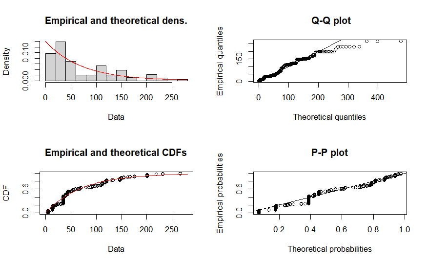

```r
linkLoc6 = which(aObs6 > 0, arr.ind=T)
withinDisp6 = cbind(distMat6[linkLoc6], aObs6[linkLoc6])

#Creating one distance observation for each individual
withinDisp6 = rep(withinDisp6[,1], withinDisp6[,2])

dispExp6 = fitdist(data = withinDisp6, distr='exp', method='mle')
plot(dispExp6)
```

```r
aObs6
```

| V1 | V2 | V3 | V4 | V5 | V7 | V8 | V9 | V10 | V11 | V12 | V13 | V14 | V15 | V16 | V17 | V18 | V19 | V20 | V21 | V22 | V23 | V24 | V25 | V26 | V27 | V28 | V29 |
| --- | --- | --- | --- | --- | --- | --- | --- | --- | --- | --- | --- | --- | --- | --- | --- | --- | --- | --- | --- | --- | --- | --- | --- | --- | --- | --- | --- |
| 0 | 0 | 0 | 0 | 0 | 0 | 0 | 0 | 0 | 0 | 0 | 0 | 0 | 0 | 0 | 0 | 0 | 0 | 0 | 0 | 0 | 0 | 0 | 0 | 0 | 0 | 0 | 0 |
| 0 | 0 | 0 | 0 | 0 | 0 | 0 | 0 | 0 | 0 | 0 | 0 | 0 | 0 | 0 | 0 | 0 | 0 | 0 | 0 | 0 | 0 | 0 | 0 | 0 | 0 | 0 | 0 |
| 0 | 0 | 0 | 0 | 1 | 0 | 0 | 0 | 0 | 0 | 0 | 0 | 0 | 0 | 0 | 0 | 0 | 0 | 0 | 0 | 0 | 0 | 0 | 0 | 1 | 1 | 0 | 0 |
| 0 | 0 | 0 | 0 | 0 | 0 | 0 | 2 | 11 | 0 | 0 | 0 | 2 | 0 | 0 | 17 | 5 | 0 | 0 | 0 | 0 | 0 | 10 | 0 | 0 | 0 | 0 | 0 |
| 0 | 0 | 0 | 0 | 0 | 0 | 0 | 0 | 0 | 0 | 0 | 0 | 0 | 0 | 0 | 0 | 0 | 0 | 1 | 0 | 0 | 0 | 0 | 0 | 1 | 1 | 0 | 0 |
| 0 | 0 | 0 | 0 | 0 | 0 | 0 | 0 | 0 | 0 | 0 | 0 | 0 | 0 | 0 | 0 | 0 | 0 | 0 | 0 | 0 | 0 | 0 | 0 | 0 | 0 | 0 | 0 |
| 0 | 0 | 0 | 0 | 0 | 0 | 0 | 0 | 0 | 0 | 0 | 0 | 0 | 0 | 0 | 0 | 0 | 0 | 0 | 0 | 0 | 0 | 0 | 0 | 0 | 0 | 0 | 0 |
| 0 | 0 | 0 | 0 | 0 | 0 | 0 | 0 | 2 | 0 | 0 | 0 | 0 | 0 | 0 | 0 | 1 | 0 | 0 | 0 | 0 | 2 | 1 | 0 | 0 | 0 | 0 | 0 |
| 0 | 0 | 0 | 13 | 1 | 0 | 0 | 5 | 0 | 0 | 0 | 0 | 1 | 0 | 0 | 3 | 18 | 0 | 3 | 0 | 0 | 1 | 48 | 0 | 0 | 1 | 0 | 0 |
| 0 | 0 | 0 | 0 | 0 | 0 | 0 | 0 | 0 | 0 | 0 | 0 | 0 | 0 | 0 | 0 | 0 | 0 | 0 | 0 | 0 | 0 | 0 | 0 | 0 | 0 | 0 | 0 |

[output cut: 18 more lines]

```r
aMeanDist6 = mean(withinDisp6)
aMeanDist6
```

```
[1] 71.77049
```

```r
aMean6 = matrix(0, nrow=nrow(aObs6), ncol=ncol(aObs6))
aMean6[distMat6 < aMeanDist6] = 1
diag(aMean6) = 0
aMean6
```

```
      [,1] [,2] [,3] [,4] [,5] [,6] [,7] [,8] [,9] [,10] [,11] [,12] [,13] [,14] [,15]
 [1,]    0    0    1    0    0    0    0    0    0     0     0     0     0     0     0
 [2,]    0    0    0    0    0    1    0    0    0     1     0     0     0     0     1
 [3,]    1    0    0    0    0    0    0    0    0     0     0     0     0     0     0
 [4,]    0    0    0    0    0    0    0    0    1     0     1     1     1     1     0
 [5,]    0    0    0    0    0    0    1    0    0     0     0     0     0     0     1
 [6,]    0    1    0    0    0    0    0    0    0     0     0     0     0     0     1
 [7,]    0    0    0    0    1    0    0    0    0     0     0     0     0     0     1
 [8,]    0    0    0    0    0    0    0    0    1     1     0     0     1     1     0
 [9,]    0    0    0    1    0    0    0    1    0     0     1     1     1     1     0
[10,]    0    1    0    0    0    0    0    1    0     0     0     0     0     0     0
[11,]    0    0    0    1    0    0    0    0    1     0     0     1     1     1     0
[12,]    0    0    0    1    0    0    0    0    1     0     1     0     1     1     0
[13,]    0    0    0    1    0    0    0    1    1     0     1     1     0     1     0
[14,]    0    0    0    1    0    0    0    1    1     0     1     1     1     0     0
```

[output cut: 43 more lines]

```r
aProb6 = matrix(0, nrow=nrow(aObs6), ncol=ncol(aObs6))
alpha6 = 1/aMeanDist6

# Calculate weights in the distance matrix
aProb6 = exp(-alpha*distMat6)
diag(aProb6)=0
aProb6
```

```
            [,1]       [,2]       [,3]       [,4]       [,5]       [,6]       [,7]
 [1,] 0.00000000 0.35001058 0.59972982 0.02027562 0.13827716 0.35312598 0.12087599
 [2,] 0.35001058 0.00000000 0.28191790 0.05742108 0.27616174 0.66259746 0.27929545
 [3,] 0.59972982 0.28191790 0.00000000 0.01664848 0.15896703 0.34001744 0.12924234
 [4,] 0.02027562 0.05742108 0.01664848 0.00000000 0.06223436 0.04827592 0.08707640
 [5,] 0.13827716 0.27616174 0.15896703 0.06223436 0.00000000 0.36983158 0.71470732
 [6,] 0.35312598 0.66259746 0.34001744 0.04827592 0.36983158 0.00000000 0.33999290
 [7,] 0.12087599 0.27929545 0.12924234 0.08707640 0.71470732 0.33999290 0.00000000
 [8,] 0.08234697 0.23005708 0.06525319 0.24432704 0.16860681 0.18226199 0.22626391
 [9,] 0.03679481 0.10399524 0.02995877 0.55067668 0.10153129 0.08623649 0.14151597
[10,] 0.19776569 0.49373410 0.14433620 0.09661135 0.18767213 0.33997331 0.21907064
[11,] 0.02822161 0.07955788 0.02286773 0.71017882 0.07909278 0.06578223 0.11046596
[12,] 0.03010327 0.08416605 0.02399017 0.63602020 0.07786846 0.06830718 0.10846644
[13,] 0.03723807 0.10591247 0.03090657 0.53784914 0.11121439 0.08974924 0.15534380
[14,] 0.03915032 0.11165851 0.03291767 0.49890865 0.12243060 0.09601351 0.17113093
```

[output cut: 101 more lines]

```r
graphAmean6 = graph_from_adjacency_matrix(aMean6, mode='undirected')
graphAprob6 = graph_from_adjacency_matrix(aProb6, mode='undirected', weighted=T)
graphAobs6 = graph_from_adjacency_matrix(as.matrix(aObs6), mode='directed', weighted=T)


# landscape level
connectance6 = edge_density(graphAmean6)
connectance6
```

```
[1] 0.3015873
```

```r
# integral index of connectivity
AL = 63990
nlMat6 = distances(graphAmean6)
nlMat6 [is.infinite(nlMat6)] = 1000
iicMat6 = outer(area6, area6)/(1+nlMat6)
iic6 = sum(iicMat6)/AL^2
iic6
```

```
[1] 0.002799433
```

```r
# probability of connectivity
pStarMat6 = distances(graphAprob6, weights=E(graphAprob6)$weight)
pStarMat6 = exp(-pStarMat6)
pcNum6 = outer(area6, area6)*pStarMat6
pc6 = sum(pcNum6)/AL^2
pc6
```

```
[1] 0.005951903
```

### Patch 7 Removed

```r
nodes7 = read.csv('https://github.com/rytomey/WILD7970_Spatial/raw/main/W12_Connectivity/kite7.csv')
area7 = nodes7$area
nodes7
```

| Name | XCoord | YCoord | area |
| --- | --- | --- | --- |
| BICY | 495505 | 2849390 | 848.2403875 |
| DEVILS | 497670 | 2925290 | 0.6780510 |
| ENP | 531302 | 2840110 | 638.3016839 |
| ETOHO | 472324 | 3130400 | 47.5983906 |
| GW | 582883 | 2962720 | 20.2262642 |
| HarnsMarsh | 431024 | 2948020 | 2.2809754 |
| HUNGRY | 569598 | 2983060 | 46.5866850 |
| IST | 472176 | 3028470 | 109.8500706 |
| KISS | 473993 | 3087280 | 145.0277254 |
| LaBelle | 461876 | 2961685 | 3.8620990 |

[output cut: 18 more lines]

```r
aObs7 = read.csv('https://github.com/rytomey/WILD7970_Spatial/raw/main/W12_Connectivity/kitemove7.csv')[,-1]
diag(aObs7) = 0
aObs7
```

| V1 | V2 | V3 | V4 | V5 | V6 | V8 | V9 | V10 | V11 | V12 | V13 | V14 | V15 | V16 | V17 | V18 | V19 | V20 | V21 | V22 | V23 | V24 | V25 | V26 | V27 | V28 | V29 |
| --- | --- | --- | --- | --- | --- | --- | --- | --- | --- | --- | --- | --- | --- | --- | --- | --- | --- | --- | --- | --- | --- | --- | --- | --- | --- | --- | --- |
| 0 | 0 | 0 | 0 | 0 | 0 | 0 | 0 | 0 | 0 | 0 | 0 | 0 | 0 | 0 | 0 | 0 | 0 | 0 | 0 | 0 | 0 | 0 | 0 | 0 | 0 | 0 | 0 |
| 0 | 0 | 0 | 0 | 0 | 0 | 0 | 0 | 0 | 0 | 0 | 0 | 0 | 0 | 0 | 0 | 0 | 0 | 0 | 0 | 0 | 0 | 0 | 0 | 0 | 0 | 0 | 0 |
| 0 | 0 | 0 | 0 | 1 | 0 | 0 | 0 | 0 | 0 | 0 | 0 | 0 | 0 | 0 | 0 | 0 | 0 | 0 | 0 | 0 | 0 | 0 | 0 | 1 | 1 | 0 | 0 |
| 0 | 0 | 0 | 0 | 0 | 0 | 0 | 2 | 11 | 0 | 0 | 0 | 2 | 0 | 0 | 17 | 5 | 0 | 0 | 0 | 0 | 0 | 10 | 0 | 0 | 0 | 0 | 0 |
| 0 | 0 | 0 | 0 | 0 | 0 | 0 | 0 | 0 | 0 | 0 | 0 | 0 | 0 | 0 | 0 | 0 | 0 | 1 | 0 | 0 | 0 | 0 | 0 | 1 | 1 | 0 | 0 |
| 0 | 0 | 0 | 0 | 0 | 0 | 0 | 0 | 0 | 0 | 0 | 0 | 0 | 0 | 0 | 0 | 1 | 0 | 0 | 0 | 0 | 0 | 1 | 0 | 0 | 0 | 0 | 0 |
| 0 | 0 | 0 | 0 | 0 | 0 | 0 | 0 | 0 | 0 | 0 | 0 | 0 | 0 | 0 | 0 | 0 | 0 | 0 | 0 | 0 | 0 | 0 | 0 | 0 | 0 | 0 | 0 |
| 0 | 0 | 0 | 0 | 0 | 0 | 0 | 0 | 2 | 0 | 0 | 0 | 0 | 0 | 0 | 0 | 1 | 0 | 0 | 0 | 0 | 2 | 1 | 0 | 0 | 0 | 0 | 0 |
| 0 | 0 | 0 | 13 | 1 | 0 | 0 | 5 | 0 | 0 | 0 | 0 | 1 | 0 | 0 | 3 | 18 | 0 | 3 | 0 | 0 | 1 | 48 | 0 | 0 | 1 | 0 | 0 |
| 0 | 0 | 0 | 0 | 0 | 0 | 0 | 0 | 0 | 0 | 0 | 0 | 0 | 0 | 0 | 0 | 0 | 0 | 0 | 0 | 0 | 0 | 0 | 0 | 0 | 0 | 0 | 0 |

[output cut: 18 more lines]

```r
coords7 = cbind(nodes7$XCoord, nodes7$YCoord)
distMat7 = pointDistance(coords7, lonlat=F)
distMat7 = distMat7 / 1000 # in km
distMat7
```

```
           [,1]      [,2]      [,3]       [,4]      [,5]      [,6]      [,7]      [,8]
 [1,]   0.00000  75.93087  36.98031 281.964499 143.10347 117.83750 152.83142 180.59316
 [2,]  75.93087   0.00000  91.57917 206.670104  93.07126  70.41550  92.25514 106.28291
 [3,]  36.98031  91.57917   0.00000 296.220675 133.01809 147.31003 147.99083 197.42182
 [4,] 281.96450 206.67010 296.22068   0.000000 200.84789 186.99774 176.55398 101.93011
 [5,] 143.10347  93.07126 133.01809 200.847890   0.00000 152.56882  24.29417 128.75986
 [6,] 117.83750  70.41550 147.31003 186.997739 152.56882   0.00000 142.93549  90.36421
 [7,] 152.83142  92.25514 147.99083 176.553977  24.29417 142.93549   0.00000 107.48541
 [8,] 180.59316 106.28291 197.42182 101.930107 128.75986  90.36421 107.48541   0.00000
 [9,] 238.86067 163.71121 253.72688  43.152288 165.44554 145.73840 141.42887  58.83806
[10,] 117.22234  51.04710 140.00161 169.038197 121.01143  33.74282 109.82222  67.57460
[11,] 258.04741 183.08540 273.26274  24.753922 183.50949 162.28823 159.34524  77.62128
[12,] 253.37885 179.01276 269.79689  32.730882 184.63787 154.86972 160.66645  72.83415
[13,] 237.99453 162.38991 251.47406  44.857074 158.85685 148.86453 134.68572  59.83547
[14,] 234.37250 158.56858 246.91436  50.293001 151.90711 148.38009 127.68508  58.38226
```

[output cut: 101 more lines]

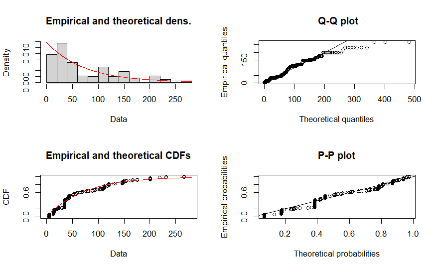

```r
linkLoc7 = which(aObs7 > 0, arr.ind=T)
withinDisp7 = cbind(distMat7[linkLoc7], aObs7[linkLoc7])

#Creating one distance observation for each individual
withinDisp7 = rep(withinDisp7[,1], withinDisp7[,2])

dispExp7 = fitdist(data = withinDisp7, distr='exp', method='mle')
plot(dispExp7)
```

```r
aObs7
```

| V1 | V2 | V3 | V4 | V5 | V6 | V8 | V9 | V10 | V11 | V12 | V13 | V14 | V15 | V16 | V17 | V18 | V19 | V20 | V21 | V22 | V23 | V24 | V25 | V26 | V27 | V28 | V29 |
| --- | --- | --- | --- | --- | --- | --- | --- | --- | --- | --- | --- | --- | --- | --- | --- | --- | --- | --- | --- | --- | --- | --- | --- | --- | --- | --- | --- |
| 0 | 0 | 0 | 0 | 0 | 0 | 0 | 0 | 0 | 0 | 0 | 0 | 0 | 0 | 0 | 0 | 0 | 0 | 0 | 0 | 0 | 0 | 0 | 0 | 0 | 0 | 0 | 0 |
| 0 | 0 | 0 | 0 | 0 | 0 | 0 | 0 | 0 | 0 | 0 | 0 | 0 | 0 | 0 | 0 | 0 | 0 | 0 | 0 | 0 | 0 | 0 | 0 | 0 | 0 | 0 | 0 |
| 0 | 0 | 0 | 0 | 1 | 0 | 0 | 0 | 0 | 0 | 0 | 0 | 0 | 0 | 0 | 0 | 0 | 0 | 0 | 0 | 0 | 0 | 0 | 0 | 1 | 1 | 0 | 0 |
| 0 | 0 | 0 | 0 | 0 | 0 | 0 | 2 | 11 | 0 | 0 | 0 | 2 | 0 | 0 | 17 | 5 | 0 | 0 | 0 | 0 | 0 | 10 | 0 | 0 | 0 | 0 | 0 |
| 0 | 0 | 0 | 0 | 0 | 0 | 0 | 0 | 0 | 0 | 0 | 0 | 0 | 0 | 0 | 0 | 0 | 0 | 1 | 0 | 0 | 0 | 0 | 0 | 1 | 1 | 0 | 0 |
| 0 | 0 | 0 | 0 | 0 | 0 | 0 | 0 | 0 | 0 | 0 | 0 | 0 | 0 | 0 | 0 | 1 | 0 | 0 | 0 | 0 | 0 | 1 | 0 | 0 | 0 | 0 | 0 |
| 0 | 0 | 0 | 0 | 0 | 0 | 0 | 0 | 0 | 0 | 0 | 0 | 0 | 0 | 0 | 0 | 0 | 0 | 0 | 0 | 0 | 0 | 0 | 0 | 0 | 0 | 0 | 0 |
| 0 | 0 | 0 | 0 | 0 | 0 | 0 | 0 | 2 | 0 | 0 | 0 | 0 | 0 | 0 | 0 | 1 | 0 | 0 | 0 | 0 | 2 | 1 | 0 | 0 | 0 | 0 | 0 |
| 0 | 0 | 0 | 13 | 1 | 0 | 0 | 5 | 0 | 0 | 0 | 0 | 1 | 0 | 0 | 3 | 18 | 0 | 3 | 0 | 0 | 1 | 48 | 0 | 0 | 1 | 0 | 0 |
| 0 | 0 | 0 | 0 | 0 | 0 | 0 | 0 | 0 | 0 | 0 | 0 | 0 | 0 | 0 | 0 | 0 | 0 | 0 | 0 | 0 | 0 | 0 | 0 | 0 | 0 | 0 | 0 |

[output cut: 18 more lines]

```r
aMeanDist7 = mean(withinDisp7)
aMeanDist7
```

```
[1] 72.32945
```

```r
aMean7 = matrix(0, nrow=nrow(aObs7), ncol=ncol(aObs7))
aMean7[distMat7 < aMeanDist7] = 1
diag(aMean7) = 0
aMean7
```

```
      [,1] [,2] [,3] [,4] [,5] [,6] [,7] [,8] [,9] [,10] [,11] [,12] [,13] [,14] [,15]
 [1,]    0    0    1    0    0    0    0    0    0     0     0     0     0     0     0
 [2,]    0    0    0    0    0    1    0    0    0     1     0     0     0     0     1
 [3,]    1    0    0    0    0    0    0    0    0     0     0     0     0     0     0
 [4,]    0    0    0    0    0    0    0    0    1     0     1     1     1     1     0
 [5,]    0    0    0    0    0    0    1    0    0     0     0     0     0     0     1
 [6,]    0    1    0    0    0    0    0    0    0     1     0     0     0     0     0
 [7,]    0    0    0    0    1    0    0    0    0     0     0     0     0     0     1
 [8,]    0    0    0    0    0    0    0    0    1     1     0     0     1     1     0
 [9,]    0    0    0    1    0    0    0    1    0     0     1     1     1     1     0
[10,]    0    1    0    0    0    1    0    1    0     0     0     0     0     0     0
[11,]    0    0    0    1    0    0    0    0    1     0     0     1     1     1     0
[12,]    0    0    0    1    0    0    0    0    1     0     1     0     1     1     0
[13,]    0    0    0    1    0    0    0    1    1     0     1     1     0     1     0
[14,]    0    0    0    1    0    0    0    1    1     0     1     1     1     0     0
```

[output cut: 43 more lines]

```r
aProb7 = matrix(0, nrow=nrow(aObs7), ncol=ncol(aObs7))
alpha7 = 1/aMeanDist7

# Calculate weights in the distance matrix
aProb7 = exp(-alpha*distMat7)
diag(aProb7)=0
aProb7
```

```
            [,1]       [,2]       [,3]       [,4]       [,5]       [,6]       [,7]
 [1,] 0.00000000 0.35001058 0.59972982 0.02027562 0.13827716 0.19609083 0.12087599
 [2,] 0.35001058 0.00000000 0.28191790 0.05742108 0.27616174 0.37774407 0.27929545
 [3,] 0.59972982 0.28191790 0.00000000 0.01664848 0.15896703 0.13046458 0.12924234
 [4,] 0.02027562 0.05742108 0.01664848 0.00000000 0.06223436 0.07536887 0.08707640
 [5,] 0.13827716 0.27616174 0.15896703 0.06223436 0.00000000 0.12131563 0.71470732
 [6,] 0.19609083 0.37774407 0.13046458 0.07536887 0.12131563 0.00000000 0.13859867
 [7,] 0.12087599 0.27929545 0.12924234 0.08707640 0.71470732 0.13859867 0.00000000
 [8,] 0.08234697 0.23005708 0.06525319 0.24432704 0.16860681 0.28669344 0.22626391
 [9,] 0.03679481 0.10399524 0.02995877 0.55067668 0.10153129 0.13333043 0.14151597
[10,] 0.19776569 0.49373410 0.14433620 0.09661135 0.18767213 0.62718377 0.21907064
[11,] 0.02822161 0.07955788 0.02286773 0.71017882 0.07909278 0.10606147 0.11046596
[12,] 0.03010327 0.08416605 0.02399017 0.63602020 0.07786846 0.11751715 0.10846644
[13,] 0.03723807 0.10591247 0.03090657 0.53784914 0.11121439 0.12769056 0.15534380
[14,] 0.03915032 0.11165851 0.03291767 0.49890865 0.12243060 0.12854867 0.17113093
```

[output cut: 101 more lines]

```r
graphAmean7 = graph_from_adjacency_matrix(aMean7, mode='undirected')
graphAprob7 = graph_from_adjacency_matrix(aProb7, mode='undirected', weighted=T)
graphAobs7 = graph_from_adjacency_matrix(as.matrix(aObs7), mode='directed', weighted=T)


# landscape level
connectance7 = edge_density(graphAmean7)
connectance7
```

```
[1] 0.2804233
```

```r
# integral index of connectivity
AL = 63990
nlMat7 = distances(graphAmean7)
nlMat7 [is.infinite(nlMat7)] = 1000
iicMat7 = outer(area7, area7)/(1+nlMat7)
iic7 = sum(iicMat7)/AL^2
iic7
```

```
[1] 0.002650867
```

```r
# probability of connectivity
pStarMat7 = distances(graphAprob7, weights=E(graphAprob7)$weight)
pStarMat7 = exp(-pStarMat7)
pcNum7 = outer(area7, area7)*pStarMat7
pc7 = sum(pcNum7)/AL^2
pc7
```

```
[1] 0.005632307
```

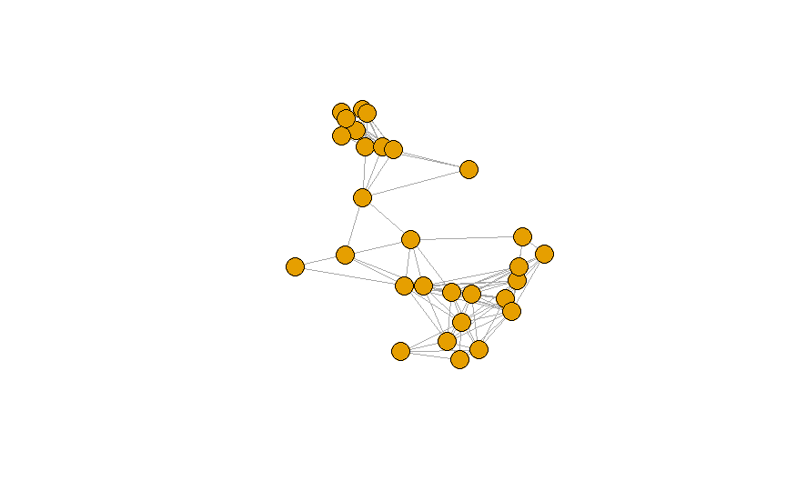

```r
plot(graphAmean, layout=coords, vertex.label=NA)
```

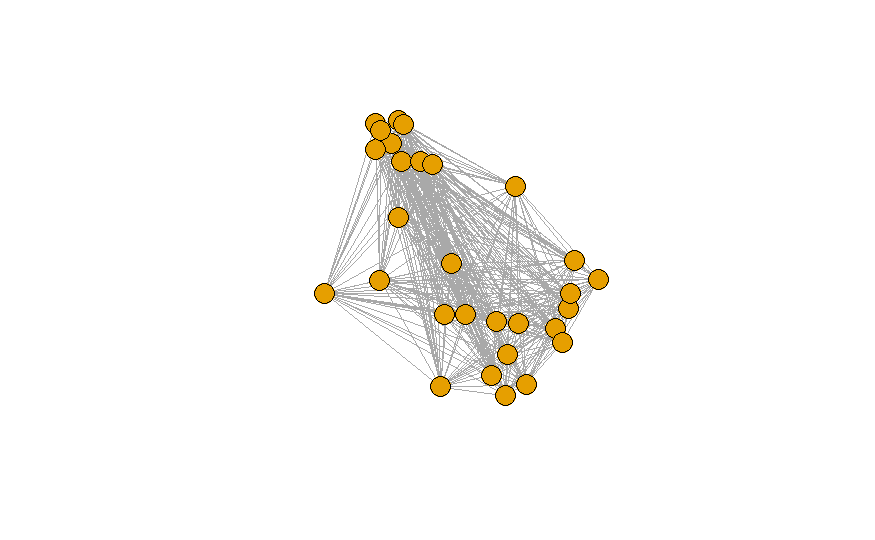

```r
plot(graphAprob, layout=coords, edge.width=E(graphAprob)$weight, vertex.label=NA)
```

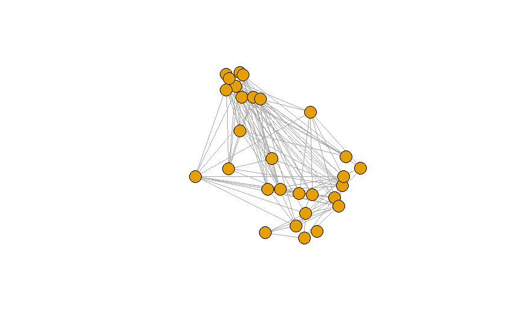

```r
plot(graphAmean6, layout=coords, vertex.label=NA)
```

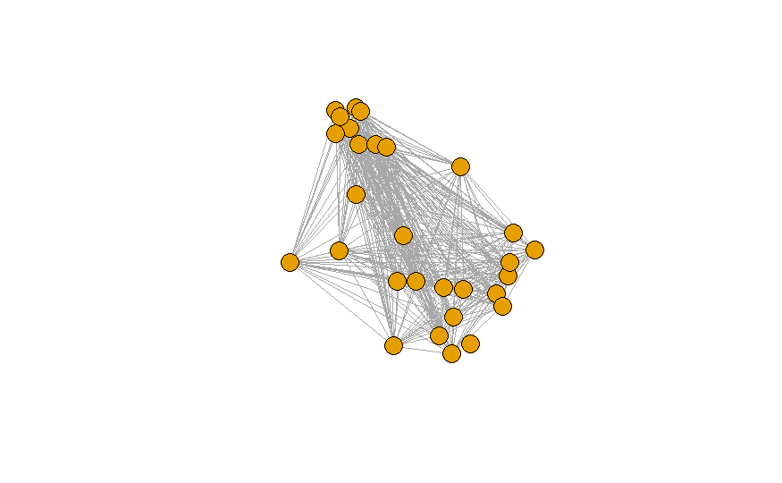

```r
plot(graphAprob6, layout=coords, edge.width=E(graphAprob)$weight, vertex.label=NA)
```

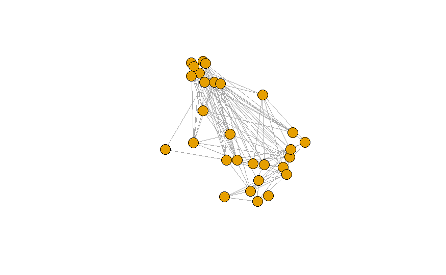

```r
plot(graphAmean7, layout=coords, vertex.label=NA)
```

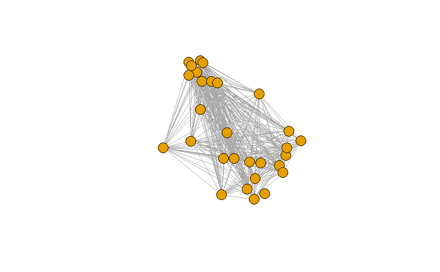

```r
plot(graphAprob7, layout=coords, edge.width=E(graphAprob)$weight, vertex.label=NA)
```

### Metrics

```r
connectance6
```

```
[1] 0.3015873
```

```r
iic6
```

```
[1] 0.002799433
```

```r
pc6
```

```
[1] 0.005951903
```

```r
connectance7
```

```
[1] 0.2804233
```

```r
iic7
```

```
[1] 0.002650867
```

```r
pc7
```

```
[1] 0.005632307
```

$\color{red}{\text{Hm, it seems you got all of the numbers right, but I'm reading this differently than you. Both IIC and PC are lower when you remove patch 7 than when you remove patch 6, so removal of patch 7 has the most negative effect on connectivity. +4 }}$